# Major capsid protein L1

Fold-switch pair **1dzlA_5keqF** — **1dzlA** vs **5keqF**

Human papillomavirus 16

## Figure 1: Phylogenetic tree with per-cluster fold-preference heatmap.

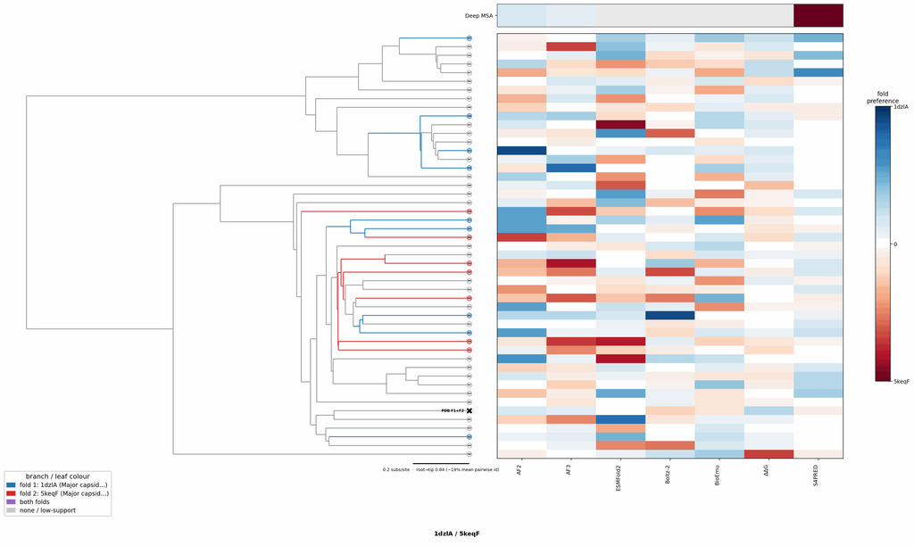

## Figure 2: Aligned overlay (both folds superposed)

The single fold-switching chain of each fold superposed by TM-align; waters hidden, any ligand shown as green sticks. Grey = structurally conserved core, colour = divergent (fold-switching) region. This pair switches fold coupled to oligomerisation; a single protomer is shown, not the full assembly.

1dzlA (Major capsid protein L1) · monomer5keqF (Major capsid protein L1) · 6-mer

TM-score: 0.930 · Trigger class: oligomerization

Aligned overlay

Loading...

## Figure 3: The two folds, side by side

Each fold is coloured by per-residue Cα deviation between the two superposed structures: grey ≈ conserved core, full colour = structurally divergent (fold-switching) region.

1dzlA (Major capsid protein L1)

5keqF (Major capsid protein L1)

0 Å5≥10 Å

1dzlA (Major capsid protein L1)

Loading...

5keqF (Major capsid protein L1)

Loading...

## Figure 4: Best-cluster predicted contact maps over the two true folds.

Predicted contact maps (MSA-Transformer) for the clusters best matching each fold, over the true contacts of fold 1 (upper triangle) and fold 2 (lower). Divergent contacts between clusters are the contact-level signature of fold-switching.

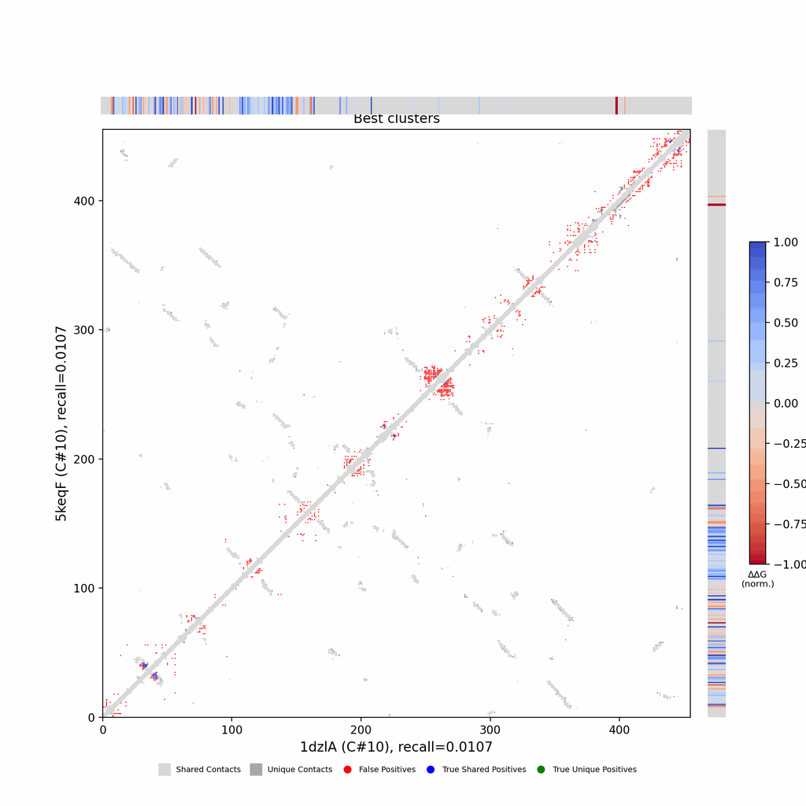

## Figure 5: Per-residue ΔΔG fold-preference contribution

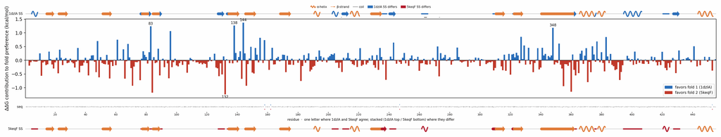

**More figures**

## Figure 6: Deep-MSA contact map panel / Best clusters contact map panel

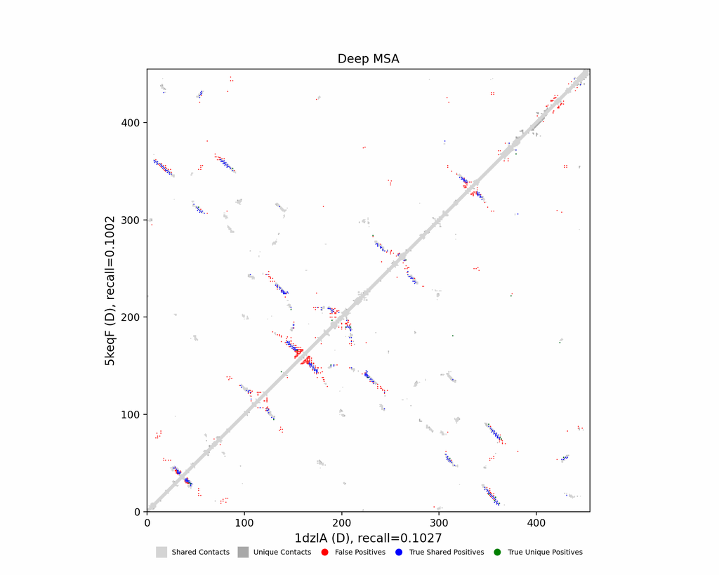

Deep-MSA contact map panel

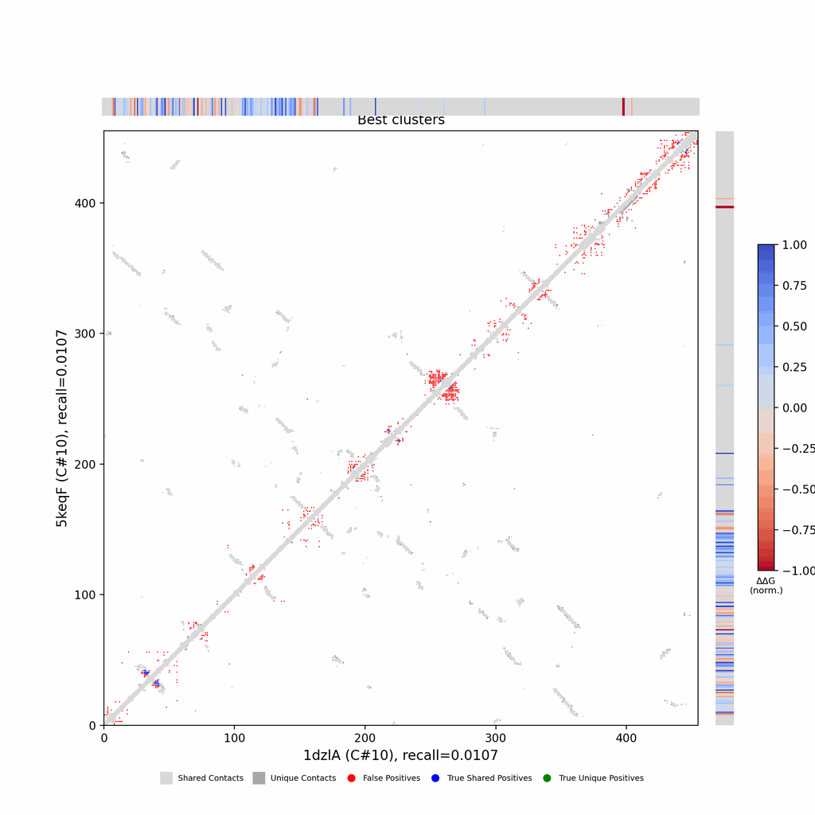

Best clusters contact map panel

## Figure 7: All clusters contact-map mosaic (small multiples).

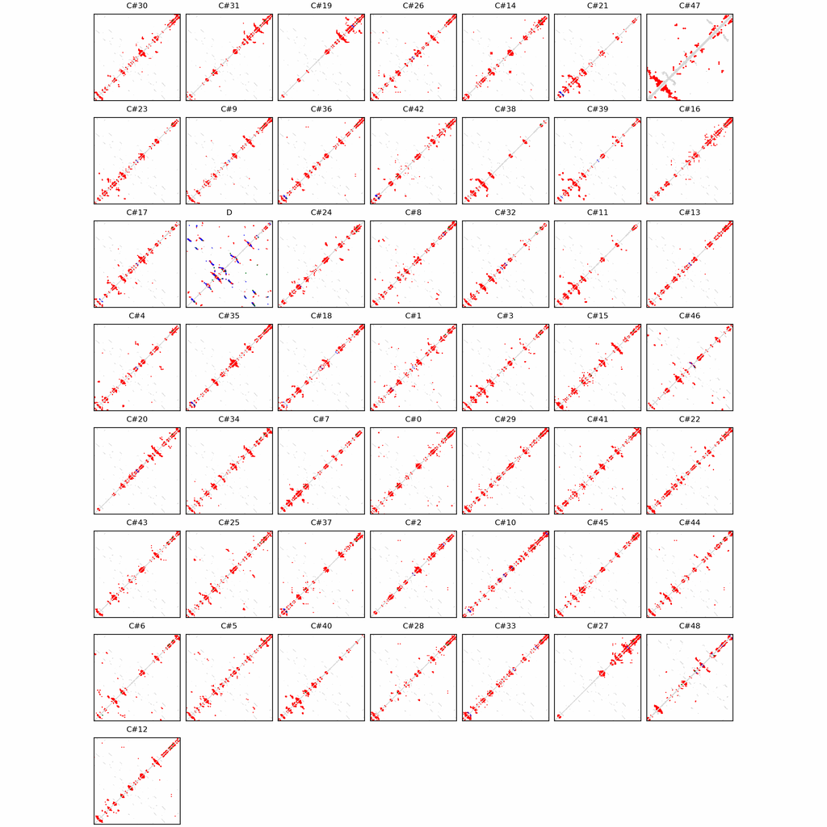

## Figure 8: Phylo null: tree with shuffled cluster fold labels.

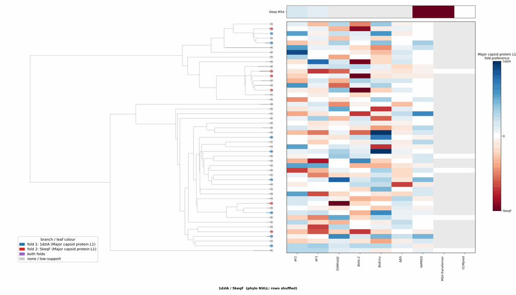

## Cluster metrics table

Per-cluster metrics underlying the figures above.

| cluster | n | neff | AF2_TM1 | AF2_TM2 | AF3_TM1 | AF3_TM2 | RE-MSAT-COM | RE-MSAT1 | RE-MSAT2 | ESM_SEQIDS | ESM_TM1 | ESM_TM2 | ΔΔG_Bias | ΔΔG_Bias_std | ΔΔG_frac_F1 | Boltz2_pref | S4PRED_pref | CCMpred_pref | BioEmu_pref |
| --- | --- | --- | --- | --- | --- | --- | --- | --- | --- | --- | --- | --- | --- | --- | --- | --- | --- | --- | --- |
| Deep | - | - | 0.92 | 0.92 | 0.93 | 0.92 | 0.26 | 0.24 | 0.25 | - | - | - | - | - | - | - | -0.03 | 0.0 | - |
| 000 | 54.0 | 6.0 | 0.2 | 0.22 | 0.25 | 0.26 | 0.0 | 0.0 | 0.0 | 003; 003; 005; 001; 007; 007; 006; 008; 010; 005 | 0.27 ± 0.07 | 0.25 ± 0.07 | -16.66 | 1.83 | 0.0 | 0.01 | -0.02 | 0.0 | 0.01 |
| 001 | 52.0 | 7.0 | 0.19 | 0.17 | 0.22 | 0.2 | 0.0 | 0.0 | 0.0 | 002; 002; 006; 006; 003; 005; 010; 010; 005; 003 | 0.26 ± 0.02 | 0.25 ± 0.02 | -11.77 | 2.9 | 0.0 | 0.07 | -0.02 | 0.0 | 0.01 |
| 002 | 52.0 | 6.0 | 0.17 | 0.17 | 0.18 | 0.19 | 0.0 | 0.0 | 0.0 | 002; 002; 001; 001; 006; 006; 005; 010; 004; 003 | 0.25 ± 0.04 | 0.25 ± 0.04 | -8.29 | 4.16 | 0.0 | -0.0 | -0.03 | 0.0 | 0.01 |
| 003 | 42.0 | 14.0 | 0.21 | 0.16 | 0.36 | 0.35 | 0.0 | 0.0 | 0.0 | 004; 006; 001; 002; 005; 008; 009; 003; 007; 010 | 0.17 ± 0.02 | 0.17 ± 0.03 | -6.35 | 3.11 | 0.0 | 0.02 | -0.03 | - | 0.01 |
| 004 | 38.0 | 9.0 | 0.19 | 0.19 | 0.21 | 0.23 | 0.0 | 0.0 | 0.0 | 004; 004; 002; 006; 008; 001; 009; 008; 005; 002 | 0.19 ± 0.01 | 0.18 ± 0.01 | -15.04 | 1.84 | 0.0 | 0.01 | -0.03 | 0.0 | 0.0 |
| 005 | 36.0 | 14.0 | 0.22 | 0.22 | 0.48 | 0.47 | 0.0 | 0.0 | 0.0 | 002; 010; 010; 008; 002; 008; 009; 007; 009; 007 | 0.26 ± 0.02 | 0.25 ± 0.01 | -11.98 | 3.66 | 0.0 | 0.01 | -0.02 | 0.0 | -0.0 |
| 006 | 35.0 | 17.0 | 0.34 | 0.34 | 0.66 | 0.64 | 0.0 | 0.0 | 0.0 | - | - | - | -17.4 | 12.52 | 0.0 | 0.0 | -0.03 | - | 0.01 |
| 007 | 34.0 | 4.0 | 0.18 | 0.17 | 0.49 | 0.46 | 0.0 | 0.0 | 0.0 | - | - | - | -8.03 | 4.37 | 0.0 | 0.01 | -0.03 | - | 0.0 |
| 008 | 34.0 | 10.0 | 0.16 | 0.16 | 0.23 | 0.22 | 0.0 | 0.0 | 0.0 | - | - | - | -9.69 | 2.68 | 0.0 | 0.02 | -0.03 | - | 0.01 |
| 009 | 34.0 | 5.0 | 0.2 | 0.2 | 0.24 | 0.23 | 0.0 | 0.0 | 0.0 | - | - | - | -7.63 | 1.39 | 0.0 | 0.01 | -0.03 | - | 0.0 |
| 010 | 34.0 | 4.0 | 0.2 | 0.19 | 0.21 | 0.19 | 0.0 | 0.0 | 0.0 | - | - | - | -2.03 | 2.2 | 0.2 | -0.01 | -0.03 | - | 0.0 |
| 011 | 33.0 | 11.0 | 0.18 | 0.18 | 0.48 | 0.48 | 0.0 | 0.0 | 0.0 | - | - | - | -7.75 | 3.73 | 0.0 | -0.03 | -0.03 | - | 0.01 |
| 012 | 32.0 | 6.0 | 0.17 | 0.16 | 0.21 | 0.21 | 0.0 | 0.0 | 0.0 | - | - | - | -12.3 | 2.28 | 0.0 | -0.01 | -0.03 | - | 0.01 |
| 013 | 32.0 | 4.0 | 0.19 | 0.16 | 0.21 | 0.2 | 0.0 | 0.0 | 0.0 | - | - | - | -13.57 | 1.85 | 0.0 | 0.01 | -0.03 | - | 0.02 |
| 014 | 32.0 | 1.0 | 0.17 | 0.18 | 0.35 | 0.34 | 0.0 | 0.0 | 0.0 | - | - | - | -10.76 | 1.93 | 0.0 | 0.01 | -0.02 | - | 0.0 |
| 015 | 30.0 | 8.0 | 0.18 | 0.15 | 0.48 | 0.47 | 0.0 | 0.0 | 0.0 | - | - | - | -12.07 | 3.64 | 0.0 | 0.01 | -0.03 | - | -0.0 |
| 016 | 30.0 | 2.0 | 0.18 | 0.18 | 0.17 | 0.19 | 0.0 | 0.0 | 0.0 | - | - | - | -4.29 | 3.34 | 0.2 | 0.01 | -0.03 | - | 0.0 |
| 017 | 28.0 | 10.0 | 0.16 | 0.17 | 0.2 | 0.18 | 0.0 | 0.0 | 0.0 | - | - | - | -5.34 | 3.29 | 0.0 | 0.01 | -0.03 | - | 0.01 |
| 018 | 28.0 | 4.0 | 0.18 | 0.17 | 0.22 | 0.2 | 0.0 | 0.0 | 0.0 | - | - | - | -8.85 | 1.85 | 0.0 | -0.01 | -0.02 | - | 0.01 |
| 019 | 27.0 | 9.0 | 0.38 | 0.37 | 0.68 | 0.66 | 0.0 | 0.0 | 0.0 | - | - | - | -14.9 | 10.99 | 0.0 | -0.0 | -0.01 | - | 0.01 |
| 020 | 26.0 | 8.0 | 0.19 | 0.19 | 0.24 | 0.23 | 0.0 | 0.0 | 0.0 | - | - | - | -7.13 | 4.16 | 0.1 | 0.0 | -0.03 | - | 0.0 |
| 021 | 26.0 | 10.0 | 0.2 | 0.18 | 0.31 | 0.3 | 0.01 | 0.01 | 0.01 | - | - | - | -6.43 | 2.14 | 0.0 | 0.0 | -0.03 | - | 0.01 |
| 022 | 26.0 | 4.0 | 0.18 | 0.18 | 0.24 | 0.23 | 0.0 | 0.0 | 0.0 | - | - | - | -10.77 | 1.61 | 0.0 | 0.0 | -0.02 | - | 0.01 |
| 023 | 26.0 | 9.0 | 0.18 | 0.18 | 0.35 | 0.34 | 0.0 | 0.0 | 0.0 | - | - | - | -10.42 | 6.14 | 0.0 | 0.01 | -0.03 | - | 0.0 |
| 024 | 26.0 | 2.0 | 0.18 | 0.18 | 0.19 | 0.18 | 0.0 | 0.0 | 0.0 | - | - | - | -13.82 | 0.79 | 0.0 | 0.01 | -0.02 | - | 0.01 |
| 025 | 26.0 | 11.0 | 0.37 | 0.36 | 0.5 | 0.49 | 0.0 | 0.0 | 0.0 | - | - | - | -10.25 | 3.79 | 0.0 | 0.01 | -0.03 | - | 0.01 |
| 026 | 25.0 | 6.0 | 0.15 | 0.17 | 0.38 | 0.37 | 0.0 | 0.0 | 0.0 | - | - | - | -11.38 | 1.3 | 0.0 | -0.0 | -0.02 | - | 0.01 |
| 027 | 24.0 | 4.0 | 0.19 | 0.2 | 0.26 | 0.26 | 0.0 | 0.0 | 0.0 | - | - | - | -2.48 | 1.79 | 0.1 | 0.01 | -0.01 | - | 0.0 |
| 028 | 24.0 | 3.0 | 0.2 | 0.16 | 0.21 | 0.23 | 0.0 | 0.0 | 0.0 | - | - | - | -16.71 | 2.01 | 0.0 | 0.01 | -0.02 | - | -0.0 |
| 029 | 24.0 | 2.0 | 0.22 | 0.23 | 0.18 | 0.21 | 0.0 | 0.0 | 0.0 | - | - | - | -11.78 | 1.49 | 0.0 | 0.03 | -0.02 | - | 0.0 |
| 030 | 24.0 | 4.0 | 0.16 | 0.16 | 0.2 | 0.21 | 0.0 | 0.0 | 0.0 | - | - | - | -12.36 | 3.59 | 0.0 | -0.04 | -0.02 | - | 0.01 |
| 031 | 24.0 | 6.0 | 0.21 | 0.19 | 0.5 | 0.5 | 0.0 | 0.0 | 0.0 | - | - | - | -2.99 | 2.57 | 0.1 | -0.01 | -0.03 | - | 0.0 |
| 032 | 23.0 | 10.0 | 0.22 | 0.2 | 0.5 | 0.49 | 0.0 | 0.0 | 0.0 | - | - | - | -7.83 | 2.91 | 0.0 | 0.0 | -0.03 | - | 0.0 |
| 033 | 22.0 | 2.0 | 0.2 | 0.16 | 0.21 | 0.18 | 0.0 | 0.0 | 0.0 | - | - | - | -14.0 | 0.86 | 0.0 | 0.0 | -0.03 | - | 0.01 |
| 034 | 22.0 | 6.0 | 0.16 | 0.17 | 0.19 | 0.21 | 0.0 | 0.0 | 0.0 | - | - | - | -10.29 | 1.48 | 0.0 | -0.03 | -0.03 | - | 0.01 |
| 035 | 22.0 | 4.0 | 0.16 | 0.16 | 0.17 | 0.18 | 0.0 | 0.0 | 0.0 | - | - | - | -16.44 | 3.53 | 0.0 | 0.0 | -0.03 | - | 0.01 |
| 036 | 22.0 | 8.0 | 0.2 | 0.16 | 0.37 | 0.36 | 0.0 | 0.0 | 0.0 | - | - | - | -11.53 | 2.44 | 0.0 | 0.03 | -0.03 | - | 0.01 |
| 037 | 22.0 | 1.0 | 0.25 | 0.24 | 0.23 | 0.23 | 0.0 | 0.0 | 0.0 | - | - | - | -12.98 | 1.54 | 0.0 | 0.0 | -0.02 | - | 0.01 |
| 038 | 21.0 | 13.0 | 0.26 | 0.26 | 0.62 | 0.57 | 0.0 | 0.0 | 0.0 | - | - | - | -6.06 | 1.5 | 0.0 | 0.01 | -0.03 | - | 0.01 |
| 039 | 21.0 | 12.0 | 0.32 | 0.3 | 0.63 | 0.6 | 0.0 | 0.0 | 0.0 | - | - | - | -7.24 | 3.42 | 0.0 | 0.0 | -0.03 | - | 0.01 |
| 040 | 21.0 | 8.0 | 0.21 | 0.21 | 0.55 | 0.53 | 0.0 | 0.0 | 0.0 | - | - | - | -12.38 | 5.72 | 0.0 | -0.01 | -0.03 | - | 0.01 |
| 041 | 20.0 | 3.0 | 0.2 | 0.16 | 0.22 | 0.21 | 0.0 | 0.0 | 0.0 | - | - | - | -8.31 | 0.96 | 0.0 | -0.0 | -0.02 | - | 0.01 |
| 042 | 20.0 | 1.0 | 0.2 | 0.18 | 0.38 | 0.37 | 0.0 | 0.0 | 0.0 | - | - | - | -14.37 | 1.14 | 0.0 | 0.0 | -0.02 | - | 0.0 |
| 043 | 20.0 | 8.0 | 0.18 | 0.17 | 0.41 | 0.4 | 0.0 | 0.0 | 0.0 | - | - | - | -8.27 | 0.85 | 0.0 | 0.0 | -0.03 | - | 0.01 |
| 044 | 20.0 | 8.0 | 0.26 | 0.25 | 0.44 | 0.43 | 0.0 | 0.0 | 0.0 | - | - | - | -8.4 | 1.63 | 0.0 | -0.03 | -0.03 | - | 0.01 |
| 045 | - | - | 0.18 | 0.18 | 0.29 | 0.29 | 0.0 | 0.0 | 0.0 | - | - | - | -12.24 | 1.36 | 0.0 | 0.01 | -0.03 | - | 0.0 |
| 046 | 16.0 | 2.0 | 0.38 | 0.38 | 0.51 | 0.5 | 0.0 | 0.0 | 0.0 | - | - | - | -33.19 | 7.42 | 0.0 | 0.02 | -0.03 | - | 0.01 |
| 047 | - | - | 0.18 | 0.18 | 0.21 | 0.2 | 0.0 | 0.0 | 0.0 | - | - | - | -3.29 | 2.93 | 0.0 | 0.01 | -0.01 | - | 0.01 |
| 048 | - | - | 0.3 | 0.29 | 0.52 | 0.5 | 0.0 | 0.01 | 0.01 | - | - | - | -20.63 | 16.7 | 0.0 | 0.01 | -0.03 | - | 0.01 |